# Supporting Complex Group Sequential Designs

March 8, 2024

## Abstract

We consider group sequential design supporting multiple objectives and possibly including complexities such as non-proportional hazards due to a delayed treatment effect. Given that off-the-shelf software has limited capabilities, we have supported a multiple open source R packages to support complex designs. The **gsDesign2** package supports design and analysis under non-proportional hazards assumptions. For testing multiple hypotheses using graphical multiplicity method, the **gMCPLite** package supports graphs and provides examples for how to analyze trials with multiple objectives. For trials testing hypotheses for multiple overlapping populations or testing of multiple experimental treatment groups versus a common control, the **wpgsd** package takes advantage of known correlations to efficiently test hypotheses. Finally, the **simtrial** package is a fast simulation tool for time-to-event endpoints. In addition to describing key package capabilities, we describe our processes to justify use in a regulatory compliant environment.

## Overview of design challenges considered

- Group sequential design using spending bounds (**gsDesign**)
  - Supporting Shiny app: https://rinpharma.shinyapps.io/gsdesign/
- Testing multiple hypotheses in group sequential design
  - **gMCPLite**: part of **gMCP** plus **ggplot2** graphics functionality
    - Supporting Shiny app: https://rinpharma.shinyapps.io/gmcp/
  - **wpgsd** package
    - MAMS (multi-arm-multi-stage)
    - Related populations (e.g., biomarker+, overall)
- Non-proportional hazards with group sequential design (**gsDesign2**)
- Fast simulation for time-to-event endpoints: **simtrial**

## Hex sticker wall

[figure not shown]

## Our design packages

| Package | Topic | Shiny interface | GitHub / Documentation | Unit test coverage |
| --- | --- | --- | --- | --- |
| gsDesign | Design | https://rinpharma.shinyapps.io/gsdesign/ | https://github.com/keaven/gsDesign https://keaven.github.io/gsDesign/ | 75% |
| gsDesign2 | NPH | Under construction | https://github.com/Merck/gsDesign2 https://merck.github.io/gsDesign2/ | 77% |
| simtrial | TTE Simulation | ? | https://github.com/Merck/simtrial https://merck.github.io/simtrial/ | 83% |
| gMCPLite | Graphical Multiplicity | https://rinpharma.shinyapps.io/gmcp/ | https://github.com/Merck/gMCPLite https://merck.github.io/gMCPLite/ | 76% |
| wpgsd | Bounds for Correlated Testing | Not currently planned | https://github.com/Merck/wpgsd https://merck.github.io/wpgsd/ | 79% |

## Graphical multiplicity

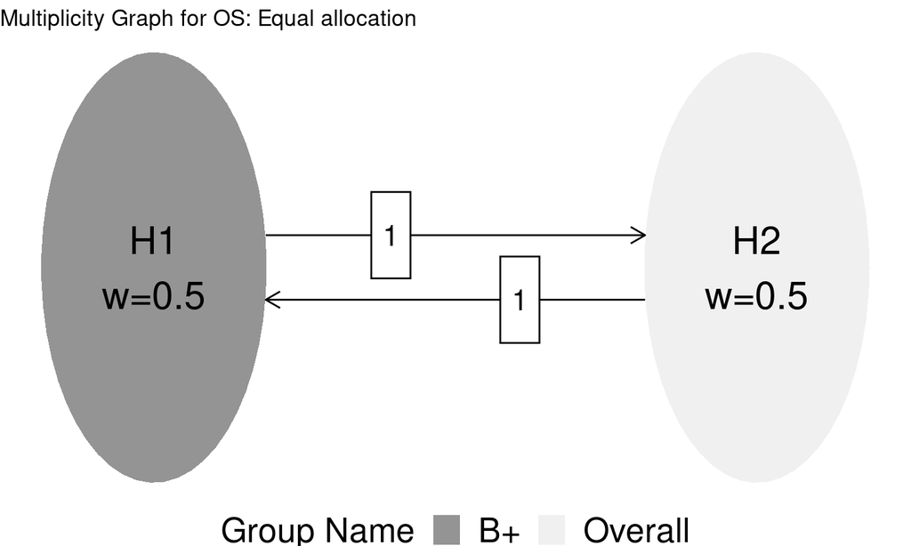

- Graph using **ggplot2** initially built with https://rinpharma.shinyapps.io/gmcp/ which generated code for **gMCPLite**
- Dividing \(\alpha\) equally between biomarker positive (B+) and overall population
- Group sequential design and \(\alpha\)-reallocation available using Maurer and Bretz (2013)
- Accounting for correlated tests, we can relax Maurer-Bretz bounds using Anderson et al. (2022) and the **wpgsd** package

## Designs

## gsDesign and its Shiny app

- The **gsDesign** package supports group sequential clinical trial design, largely as presented by Jennison and Turnbull (1999). An easy-to-use web interface to enable usage without coding as well as generate code to reproduce a design; this is being enhanced to support more features on an ongoing basis.
- Initial OS design for B+ group assumes
  - \(\alpha= 0.01\), 90% power
  - Median control OS = 12 months
  - Hazard ratio (HR) for experimental treatment = 0.6
  - 12 month enrollment with 6 month ramp-up
  - Analyses planned at 16, 26, and 36 months
  - O’Brien-Fleming-like spending bound

Design Using Calendar timing

gsDesign::gsSurvCalendar()

| Analysis | Value | Efficacy |
| --- | --- | --- |
| IA 1: 45% | p (1-sided) | 0.0001 |
| N: 284 | ~HR at bound | 0.4648 |
| Events: 91 | P(Cross) if HR=1 | 0.0001 |
| Month: 16 | P(Cross) if HR=0.6 | 0.1134 |
| IA 2: 79% | p (1-sided) | 0.0037 |
| N: 284 | ~HR at bound | 0.6542 |
| Events: 159 | P(Cross) if HR=1 | 0.0038 |
| Month: 26 | P(Cross) if HR=0.6 | 0.7118 |
| Final | p (1-sided) | 0.0088 |
| N: 284 | ~HR at bound | 0.7156 |
| Events: 201 | P(Cross) if HR=1 | 0.0100 |
| Month: 36 | P(Cross) if HR=0.6 | 0.9003 |

Information- or calendar-based spending supported  
Table often incoporated directly into protocol

## gsDesign2

- **Introduction**: The goal of gsDesign2 is to enable fixed or group sequential design under non-proportional hazards, including changing hazard ratios over time and/or between strata. Substantial flexibility on top of what **gsDesign** provides (Zhao et al. (2023)).
- Reproducing same design as **gsDesign** with different sample size method: `gs_design_ahr()`.
- Results close, but slightly different from **gsDesign**.
  - Does this mean one is wrong?
  - We will check using simulation!

Design for B+ Population Using gs_design_ahr()

AHR approximations of ~HR at bound

| Bound | Z | Nominal p<sup>1</sup> | ~HR at bound<sup>2</sup> | Cumulative boundary crossing probability Alternate hypothesis | Cumulative boundary crossing probability Null hypothesis |
| --- | --- | --- | --- | --- | --- |
| Analysis: 1 Time: 15.9 N: 278 Event: 89 AHR: 0.6 Information fraction: 0.44 |  |  |  |  |  |
| Efficacy | 3.67 | 0.0001 | 0.4520 | 0.1088 | 0.0001 |
| Analysis: 2 Time: 25.8 N: 278 Event: 155 AHR: 0.6 Information fraction: 0.77 |  |  |  |  |  |
| Efficacy | 2.69 | 0.0036 | 0.6453 | 0.6865 | 0.0036 |
| Analysis: 3 Time: 36.2 N: 278 Event: 198 AHR: 0.6 Information fraction: 1 |  |  |  |  |  |
| Efficacy | 2.37 | 0.0089 | 0.7121 | 0.9016 | 0.0100 |

<sup>1</sup> One-sided p-value for experimental vs control treatment. Value < 0.5 favors experimental, > 0.5 favors control.  
<sup>2</sup> Approximate hazard ratio to cross bound.

## gsDesign vs. gsDesign2

| Feature | gsDesign | gsDesign2 |
| --- | --- | --- |
| Nonproportional hazards | ❌ | ✔️ |
| Allow skipping bound at an analysis | ❌ | ✔️ |
| Integer-based sample size/event count | ✔️ | ✔️ |
| Alternates to logrank for survival analysis | ❌ | ✔️ |
| Calendar-based timing/spending | ✔️ | ✔️ |
| HR bounds for futility | ❌ | ✔️ |
| Stratified design for binomial | ❌ | ✔️ |
| Shiny interface | ✔️ | Under construction |
| Maturity | ✔️ | ❌ |

## Simulations

## simtrial

- **simtrial**: fast, extensible clinical trial simulation framework for time-to-event endpoints.
  - Backend based on **data.table**
- For each simulation
  - Generate data: `sim_pw_surv()`
  - For each analysis
    - Cut the data for analysis: `create_cutting()`; function factory allowing complex rules
    - Create Z-value test for analysis: various tests available; logrank shown here
- Across simulations: summarize trial outcomes

10k simulations for design power

Requiring event count and minimum follow-up helpful

| Cut criteria | Power (95% CI) |
| --- | --- |
| Event count | 88.6%, 95% CI: (88%, 89.2%) |
| Event count and minimum follow-up | 94.4%, 95% CI: (93.9%, 94.9%) |

## Non-proportional hazards

- For Biomarker- group population, assume delayed effect.
  - 3 months: HR = 1
  - Thereafter: HR = 0.7.
  - 30% of overall population.
- Sample size determined by B+ population already derived.
- Spending for both B+ and overall determined by B+ information fraction.
- Power computed here using `gs_power_ahr()`.
- Design assumes stratified analysis (B+, B-).

Overall Population Design

AHR approximations of ~HR at bound

| Bound | Z | Nominal p<sup>1</sup> | ~HR at bound<sup>2</sup> | Cumulative boundary crossing probability Alternate hypothesis | Cumulative boundary crossing probability Null hypothesis<sup>3</sup> |
| --- | --- | --- | --- | --- | --- |
| Analysis: 1 Time: 15.9 N: 398 Event: 130 AHR: 0.65 Information fraction: 0.45 |  |  |  |  |  |
| Efficacy | 3.63 | 0.0001 | 0.5227 | 0.1304 | 0.0001 |
| Analysis: 2 Time: 25.9 N: 398 Event: 225 AHR: 0.63 Information fraction: 0.78 |  |  |  |  |  |
| Efficacy | 2.67 | 0.0038 | 0.6971 | 0.7993 | 0.0038 |
| Analysis: 3 Time: 36 N: 398 Event: 284 AHR: 0.62 Information fraction: 1 |  |  |  |  |  |
| Efficacy | 2.37 | 0.0088 | 0.7530 | 0.9617 | 0.0100 |

<sup>1</sup> One-sided p-value for experimental vs. control treatment. Value < 0.5 favors experimental, > 0.5 favors control.  
<sup>2</sup> Approximate hazard ratio to cross bound.  
<sup>3</sup> alpha-spending determined by B+ information fraction.

## wpgsd

Weighted parametric group sequential design

- WPGSD; Anderson et al. (2022)
- Takes advantage of the known correlation structure in constructing efficacy bounds
- Controls family-wise Type I error (FWER) for a group sequential design.
- Correlation may be due to:
  - common observations in nested populations
  - overlapping populations
  - common control arm.

Counting events that occur in intersection hypotheses

| H1 | H2 | Analysis | Event |
| --- | --- | --- | --- |
| 1 | 1 | 1 | 89 |
| 1 | 1 | 2 | 155 |
| 1 | 1 | 3 | 198 |
| 1 | 2 | 1 | 89 |
| 1 | 2 | 2 | 155 |
| 1 | 2 | 3 | 198 |
| 2 | 2 | 1 | 130 |
| 2 | 2 | 2 | 225 |
| 2 | 2 | 3 | 284 |

## Correlation Matrix and Bounds

Correlation matrix

Correlations Between Tests

| H1_A1 | H2_A1 | H1_A2 | H2_A2 | H1_A3 | H2_A3 |
| --- | --- | --- | --- | --- | --- |
| 1.00 | 0.83 | 0.76 | 0.63 | 0.67 | 0.56 |
| 0.83 | 1.00 | 0.63 | 0.76 | 0.55 | 0.68 |
| 0.76 | 0.63 | 1.00 | 0.83 | 0.88 | 0.74 |
| 0.63 | 0.76 | 0.83 | 1.00 | 0.73 | 0.89 |
| 0.67 | 0.55 | 0.88 | 0.73 | 1.00 | 0.83 |
| 0.56 | 0.68 | 0.74 | 0.89 | 0.83 | 1.00 |

Bounds

| Analysis | Hypotheses | H1 | H2 |
| --- | --- | --- | --- |
| 1 | H1 | 0.00083 | NA |
| 1 | H1, H2 | 0.00048 | 0.00048 |
| 1 | H2 | NA | 0.00083 |
| 2 | H1 | 0.011 | NA |
| 2 | H1, H2 | 0.0069 | 0.0069 |
| 2 | H2 | NA | 0.011 |
| 3 | H1 | 0.022 | NA |
| 3 | H1, H2 | 0.014 | 0.014 |
| 3 | H2 | NA | 0.022 |

## Group Sequential Bound Comparison: Bonferroni vs. Parametric

Usual group sequential calculation

Bonferroni Bounds

Adjusted only for correlations between analyses

| Analysis | Hypotheses | H1 | H2 |
| --- | --- | --- | --- |
| 1 | H1 | 0.00083 | NA |
| 1 | H1, H2 | 0.00019 | 0.00019 |
| 1 | H2 | NA | 0.00083 |
| 2 | H1 | 0.011 | NA |
| 2 | H1, H2 | 0.0047 | 0.0047 |
| 2 | H2 | NA | 0.011 |
| 3 | H1 | 0.022 | NA |
| 3 | H1, H2 | 0.011 | 0.011 |
| 3 | H2 | NA | 0.022 |

Bounds expressed as nominal p-values

WPGSD

Weighted Parametric GSD

Adjusted for correlations between analyses and hypotheses

| Analysis | Hypotheses | H1 | H2 |
| --- | --- | --- | --- |
| 1 | H1 | 0.00083 | NA |
| 1 | H1, H2 | 0.00048 | 0.00048 |
| 1 | H2 | NA | 0.00083 |
| 2 | H1 | 0.011 | NA |
| 2 | H1, H2 | 0.0069 | 0.0069 |
| 2 | H2 | NA | 0.011 |
| 3 | H1 | 0.022 | NA |
| 3 | H1, H2 | 0.014 | 0.014 |
| 3 | H2 | NA | 0.022 |

Bounds expressed as nominal p-values

## Summary

- Validated R-based packages for complex group sequential design
- Substantial documentation and examples available
- Key features include:
  - Non-proportional hazards
  - Specialized spending and other bounds
  - Liberalizing bounds by incorporating known correlations
  - Summary output formatted for formal documents

## Thank you

**Email:** keaven_anderson@merck.com

**Slides:** https://keaven.github.io/talks/

## References

Anderson, Keaven M, Zifang Guo, Jing Zhao, and Linda Z Sun. 2022. “A Unified Framework for Weighted Parametric Group Sequential Design.” *Biometrical Journal* 64 (7): 1219–39.

Jennison, Christopher, and Bruce W Turnbull. 1999. *Group Sequential Methods with Applications to Clinical Trials*. CRC Press.

Maurer, Willi, and Frank Bretz. 2013. “Multiple Testing in Group Sequential Trials Using Graphical Approaches.” *Statistics in Biopharmaceutical Research* 5 (4): 311–20.

Zhao, Yujie, Yilong Zhang, Larry Leon, and Keaven M Anderson. 2023. “Group Sequential Design Under Non-Proportional Hazards.” *arXiv Preprint arXiv:2312.01723*.